# Part I - PISA2012 Dataset Exploration

## Introduction

> The PISA - **[Programme for International Student Assessment](https://www.oecd.org/pisa/)** - 2012 Data is a survey of students' skills and knowledge as they approach the end of compulsory education. The survey examines one: how well students have learned the school curriculum; two: how well prepared they are for life beyond school.\ About 490,000 15-year-old students in 65 economies contained in this dataset took part in the PISA2012 assessment of reading,mathematics, and science. The assessment is a measure of their ability to use these knowledge and skills to meet real life challenges. Of those economies, 44 economies took part in an assessment of creative problem solving, and 18 economies took part in an assessment of financial literacy. The dataset contains a wealth of information on students' background, their school and the organisation of education system.

## Preliminary Wrangling

```python
# import all packages and set plots to be embedded inline
import numpy as np
import pandas as pd
import matplotlib.pyplot as plt
import seaborn as sb
from timeit import default_timer as timer

%matplotlib inline
```

## Gathering Data

```python
# to determine the encoding type of the dataset.
with open("pisa2012.csv") as f:
    print(f)
```

```
<_io.TextIOWrapper name='pisa2012.csv' mode='r' encoding='cp1252'>
```

```python
# It takes about 90 seconds to read the entire dataset.
start = timer()

#read dataset to a Pandas Dataframe
pisa_df = pd.read_csv("pisa2012.csv",encoding='cp1252')

# print total time taken in seconds
end = timer()
print('{:.2f}'.format(end-start),'seconds')
```

```
83.54 seconds
```

```python
# check to see if dataset was loaded correctly
pisa_df.head(5)
```

|  | Unnamed: 0 | CNT | SUBNATIO | STRATUM | OECD | NC | SCHOOLID | STIDSTD | ST01Q01 | ST02Q01 | ... | W_FSTR75 | W_FSTR76 | W_FSTR77 | W_FSTR78 | W_FSTR79 | W_FSTR80 | WVARSTRR | VAR_UNIT | SENWGT_STU | VER_STU |
| --- | --- | --- | --- | --- | --- | --- | --- | --- | --- | --- | --- | --- | --- | --- | --- | --- | --- | --- | --- | --- | --- |
| 0 | 1 | Albania | 80000 | ALB0006 | Non-OECD | Albania | 1 | 1 | 10 | 1.0 | ... | 13.7954 | 13.9235 | 13.1249 | 13.1249 | 4.3389 | 13.0829 | 19 | 1 | 0.2098 | 22NOV13 |
| 1 | 2 | Albania | 80000 | ALB0006 | Non-OECD | Albania | 1 | 2 | 10 | 1.0 | ... | 13.7954 | 13.9235 | 13.1249 | 13.1249 | 4.3389 | 13.0829 | 19 | 1 | 0.2098 | 22NOV13 |
| 2 | 3 | Albania | 80000 | ALB0006 | Non-OECD | Albania | 1 | 3 | 9 | 1.0 | ... | 12.7307 | 12.7307 | 12.7307 | 12.7307 | 4.2436 | 12.7307 | 19 | 1 | 0.1999 | 22NOV13 |
| 3 | 4 | Albania | 80000 | ALB0006 | Non-OECD | Albania | 1 | 4 | 9 | 1.0 | ... | 12.7307 | 12.7307 | 12.7307 | 12.7307 | 4.2436 | 12.7307 | 19 | 1 | 0.1999 | 22NOV13 |
| 4 | 5 | Albania | 80000 | ALB0006 | Non-OECD | Albania | 1 | 5 | 9 | 1.0 | ... | 12.7307 | 12.7307 | 12.7307 | 12.7307 | 4.2436 | 12.7307 | 19 | 1 | 0.1999 | 22NOV13 |

5 rows × 636 columns

## Assessing Data

```python
pisa_df.shape
```

```
(485490, 636)
```

```python
pisa_df.info(10)
```

```
<class 'pandas.core.frame.DataFrame'>
RangeIndex: 485490 entries, 0 to 485489
Data columns (total 636 columns):
 #    Column       Dtype
---   ------       -----
 0    Unnamed: 0   int64
 1    CNT          object
 2    SUBNATIO     int64
 3    STRATUM      object
 4    OECD         object
 5    NC           object
 6    SCHOOLID     int64
 7    STIDSTD      int64
 8    ST01Q01      int64
 9    ST02Q01      float64
```

[output cut: 628 more lines]

```python
# check for duplicated rows
pisa_df.duplicated().sum()
```

```
0
```

```python
# An attempt to drop NaN using .drop() left me with no single row in the dataframe
# investigating to check if there was actually a column that has all values to be null across its rows, the ouput (636) means "No"
Null_list = pisa_df.isna().sum()

i = 0
for value in Null_list:
    if (value==485490):
        print(i)

    i = i+1
print(i)
```

```
636
```

```python
# check for Nan values in specific columns
pisa_df['OUTHOURS'].isna().sum()
```

```
176691
```

```python
# counts of unique values
pisa_df['ST29Q01'].value_counts()
```

```
Disagree             122898
Agree                100609
Strongly disagree     63638
Strongly agree        28766
Name: ST29Q01, dtype: int64
```

```python
# counts of unique values
pisa_df['ST44Q05'].value_counts()
```

```
Likely               139516
Very   Likely         80794
Slightly likely       67979
Not at all likely     24707
Name: ST44Q05, dtype: int64
```

```python
# data assessment
pisa_df.tail(5)
```

|  | Unnamed: 0 | CNT | SUBNATIO | STRATUM | OECD | NC | SCHOOLID | STIDSTD | ST01Q01 | ST02Q01 | ... | W_FSTR75 | W_FSTR76 | W_FSTR77 | W_FSTR78 | W_FSTR79 | W_FSTR80 | WVARSTRR | VAR_UNIT | SENWGT_STU | VER_STU |
| --- | --- | --- | --- | --- | --- | --- | --- | --- | --- | --- | --- | --- | --- | --- | --- | --- | --- | --- | --- | --- | --- |
| 485485 | 485486 | Vietnam | 7040000 | VNM0317 | Non-OECD | Viet Nam | 162 | 4955 | 10 | 3.0 | ... | 31.2413 | 93.7238 | 93.7238 | 93.7238 | 93.7238 | 31.2413 | 41 | 1 | 0.0653 | 22NOV13 |
| 485486 | 485487 | Vietnam | 7040000 | VNM0317 | Non-OECD | Viet Nam | 162 | 4956 | 10 | 3.0 | ... | 33.9163 | 96.0036 | 96.0036 | 96.0036 | 96.0036 | 33.9163 | 41 | 1 | 0.0688 | 22NOV13 |
| 485487 | 485488 | Vietnam | 7040000 | VNM0317 | Non-OECD | Viet Nam | 162 | 4957 | 10 | 3.0 | ... | 33.9163 | 96.0036 | 96.0036 | 96.0036 | 96.0036 | 33.9163 | 41 | 1 | 0.0688 | 22NOV13 |
| 485488 | 485489 | Vietnam | 7040000 | VNM0317 | Non-OECD | Viet Nam | 162 | 4958 | 10 | 3.0 | ... | 33.9163 | 96.0036 | 96.0036 | 96.0036 | 96.0036 | 33.9163 | 41 | 1 | 0.0688 | 22NOV13 |
| 485489 | 485490 | Vietnam | 7040000 | VNM0317 | Non-OECD | Viet Nam | 162 | 4959 | 10 | 3.0 | ... | 31.2413 | 93.7238 | 93.7238 | 93.7238 | 93.7238 | 31.2413 | 41 | 1 | 0.0653 | 22NOV13 |

5 rows × 636 columns

```python
pisa_df['PV1MATH'].describe()
```

```
count    485490.000000
mean        469.621653
std         103.265391
min          19.792800
25%         395.318600
50%         466.201900
75%         541.057800
max         962.229300
Name: PV1MATH, dtype: float64
```

```python
pisa_df['ST26Q10'].isna().sum()
```

```
14248
```

```python
pisa_df['OUTHOURS'].describe()
```

```
count    308799.000000
mean         11.104100
std          10.476669
min           0.000000
25%           4.000000
50%           8.000000
75%          14.000000
max         180.000000
Name: OUTHOURS, dtype: float64
```

```python
pisa_df['ST94Q14'].value_counts()
```

```
Somewhat like me      85259
Not much like me      72788
Mostly like me        62654
Very much like me     48749
Not at all like me    42551
Name: ST94Q14, dtype: int64
```

```python
pisa_df['ST94Q14'].isna().sum()
```

```
173489
```

## Cleaning Data

#### Copy Dataframe

```python
# make a copy
pisa_clean_df = pisa_df.copy()
```

### Quality Issue: Presence of irrelevant "Unnamed" column

#### Define : Remove "Unnamed" column from the dataset using the `drop()` function.

#### Code

```python
# drop "Unnamed" column
pisa_clean_df.drop(pisa_clean_df.columns[pisa_clean_df.columns.str.contains("Unnamed")], axis=1, inplace=True)
```

#### Test:

```python
pisa_clean_df.head(1)
```

|  | CNT | SUBNATIO | STRATUM | OECD | NC | SCHOOLID | STIDSTD | ST01Q01 | ST02Q01 | ST03Q01 | ... | W_FSTR75 | W_FSTR76 | W_FSTR77 | W_FSTR78 | W_FSTR79 | W_FSTR80 | WVARSTRR | VAR_UNIT | SENWGT_STU | VER_STU |
| --- | --- | --- | --- | --- | --- | --- | --- | --- | --- | --- | --- | --- | --- | --- | --- | --- | --- | --- | --- | --- | --- |
| 0 | Albania | 80000 | ALB0006 | Non-OECD | Albania | 1 | 1 | 10 | 1.0 | 2 | ... | 13.7954 | 13.9235 | 13.1249 | 13.1249 | 4.3389 | 13.0829 | 19 | 1 | 0.2098 | 22NOV13 |

1 rows × 635 columns

### Quality Issue: Presence of missing values - NaN

#### Define: Remove row with null values using `dropna()` function

#### Code

```python
# drop null values in specific columns of interest
pisa_clean_df = pisa_clean_df.dropna(subset=['ST26Q10','ST29Q01','ST44Q05','OUTHOURS','ST94Q14'])
# reset dataframe index
pisa_clean_df = pisa_clean_df.reset_index(drop=True)
```

#### Test

```python
pisa_clean_df.shape
```

```
(148250, 635)
```

```python
pisa_clean_df['ST94Q14'].isna().sum()
```

```
0
```

```python
pisa_clean_df['ST04Q01'].isna().sum()
```

```
0
```

### Quality Issue : Some ordinal variables are not of `category` data type

#### Define:

Create a function to convert the ordinal columns of interest to categorical data type, in order to minimize repetitve coding.

#### Code

```python
# a function to convert a column to category datatype
def categorize(column_name,column_class):
    """A private function convert the input column of an already defined
     dataframe into a category datatype.
    It's first argument should be the column name,its second argument
    should be a variable that's already assigned an array - this array
    should have been arranged in its right order.

    e.g. categorize('cat_var','cat_class')"""

    classes = pd.api.types.CategoricalDtype(ordered=True,categories=column_class)
    pisa_clean_df[column_name] = pisa_clean_df[column_name].astype(classes);
```

```python
# create an array for the order of values
classes_1 = ['Strongly disagree','Disagree','Agree','Strongly agree']
classes_2 = ['Not at all likely','Slightly likely','Likely','Very   Likely']
classes_3 = ['Not at all like me','Not much like me','Somewhat like me','Very much like me','Mostly like me']
# call function to make conversion
categorize('ST29Q01',classes_1)
categorize('ST44Q05',classes_2)
categorize('ST94Q14',classes_3)
```

#### Test

```python
pisa_clean_df['ST29Q01'].dtype
```

```
CategoricalDtype(categories=['Strongly disagree', 'Disagree', 'Agree', 'Strongly agree'], ordered=True)
```

```python
pisa_clean_df['ST44Q05'].dtype
```

```
CategoricalDtype(categories=['Not at all likely', 'Slightly likely', 'Likely',
                  'Very   Likely'],
, ordered=True)
```

### What is the structure of your dataset?

> There are 485,490 students in this dataset, and it has 636 columns - most of which are qualitative in nature. The numerous columns are an exhaustive assessment of each student,and can be broadly categorised into three:
> 1. Data on students' background,school and education system.
> 2. Assessment data of students' skills and knowledge in mathematics,science and reading.
> 3. Assessment data of students capability to tackle real life challenges after school.

### What is/are the main feature(s) of interest in your dataset?

> I am most interested in finding the factors that affect or are directly related to the performance of pupils in Mathematics asessment.

### What features in the dataset do you think will help support your investigation into your feature(s) of interest?

> "Gender" (ST04Q01); "Out-of-School Study Time" (OUTHOURS); "Interest in Mathematics" (ST29Q01);"Possession - textbooks"(ST26Q10), and lastly "Attribution to failure - Material too hard" (ST44Q05).

## Univariate Exploration

#### Question 1:

What is the distribution of the main variable of interest - 'PV1MATH' (students performance in mathematics) ?

#### Visualization

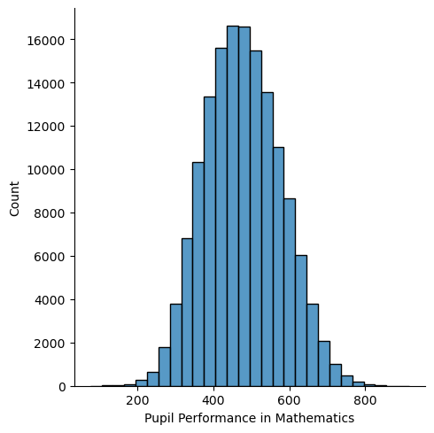

```python
# histogram distribution of Pupil performance in Mathematics.
bin_edges = np.arange(pisa_clean_df['PV1MATH'].min(),pisa_clean_df['PV1MATH'].max()+30,30)
sb.displot(pisa_clean_df['PV1MATH'], bins=bin_edges);
plt.xlabel('Pupil Performance in Mathematics');
```

#### Observation:

A unimodal normal distribution. It has its peak around the performance value of 450.

\ Next up is the first predictor variable: "ST26Q10" Possessions - Textbooks.

*Since the data set has a lot of Qualitative variables, in order to minimize code repetiton, I'll be creating a function below to plot a barchart and its axis label for univariate analysis of Qualitative variables.*

```python
# a function to simply generate a barchart plot, for all qualitative variable in the  cleaned dataframe
def barchart(x,label_name,long=False):

    """This barchart() function simply generates a seaborn.countplot() function,
    and customize the specified axis label with a plt.xlabel() or plt.ylabel() function call.

    The first argument is the name of the column to be plotted ,
    The second argument is the x_label or y_label,
    By default long = False, set long to true if you want the qualitative column
    on the y-axis instead.
    e.g. barchart('column_name','x_or_ylabel',long=True)"""


    base_color = sb.color_palette()[0]
    if (long==True):
        sb.countplot(data=pisa_clean_df,y=x,color=base_color);
        plt.ylabel(label_name);

    else:
        sb.countplot(data=pisa_clean_df,x=x,color=base_color);
        plt.xlabel(label_name);
```

#### Question 2:

How many students possess textbooks and how many do not 'ST26Q10' ?

#### Visualization

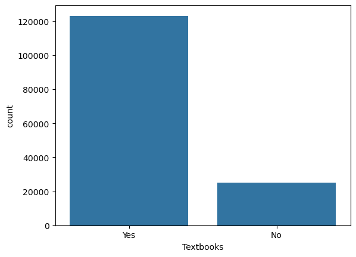

```python
# a barchart of Possession - Textbooks
barchart('ST26Q10','Textbooks')
```

#### Observation:

About 120,000 students possess textbooks for personal study, and about 20,000 do not.

\ I'd like to take students' interest in Mathematics as the next predictor variable.

#### Question 3:

What is the comparison of students' interest in mathematics,do they enjoy reading it 'ST29Q01'?

#### Visualization

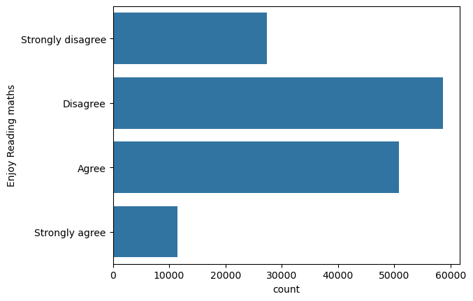

```python
# a barchart of "Interest in Mathematics - Enjoy Reading"
barchart('ST29Q01','Enjoy Reading maths',long=True)
```

#### Observation:

The pupils who disagreed are the highest,while a slightly lesser number of pupils agreed. Overall more pupils chose the negative side of the scale (disagree and strongly disagree) than those who chose the positive side (agree and strongly agree).

#### Question 4:

Attribution to failure - is the material too hard ("ST44Q05")?

#### Visualization

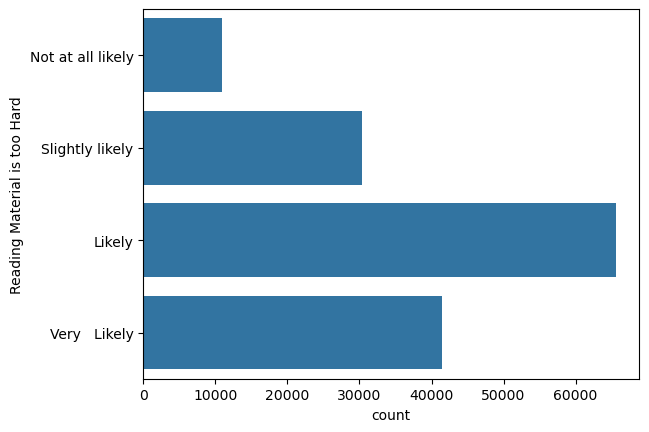

```python
# create a barchart of 'Attribution to failure - Material too Hard'
barchart('ST44Q05',"Reading Material is too Hard",long=True)
```

#### Question 5:

Distribution of students' "out of school study hours" ?

#### Visualization

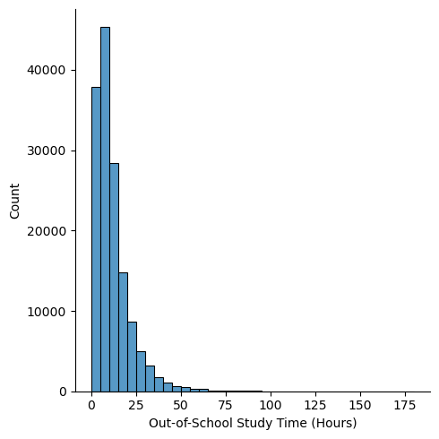

```python
# plot histogram distribution of 'out-of-school study time'
bin_edges = np.arange(0,180+5,5)
sb.displot(pisa_clean_df['OUTHOURS'], bins=bin_edges);
plt.xlabel('Out-of-School Study Time (Hours)');
```

The above distribution is rightly skewed, so I thought of performing a log transformation. However,a log transformation cannot be applied directly because of '0' values in the data.\ Since a '0.001' hour is as good as '0.0' hour, I replaced all '0.0' in the column to '0.001'. Now a log transformation is possible because zeroes have been eliminated.

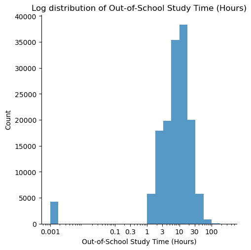

```python
# replace 0 hours with 0.001 in the OUTHOURS column
pisa_clean_df['OUTHOURS'] = pisa_clean_df['OUTHOURS'].replace([0.0],0.001)
# set x-ticks
ticks = [0.001,0.1,0.3,1,3,10,30,100]
# set bin edges, and create plot
bin_edges = 10**np.arange(-3,2.26 + 0.25,0.25)
sb.displot(pisa_clean_df['OUTHOURS'], bins=bin_edges);
plt.xlabel('Out-of-School Study Time (Hours)');
# apply scaling and log transformation
plt.xscale('log')
plt.xticks(ticks,ticks);
plt.title("Log distribution of Out-of-School Study Time (Hours)");
```

#### Question 6:

1. What is the ratio of students that come from OECD country and Non-OECD?
2. What is the ratio of female to male students that took part in the PISA assessment.

#### Visualization

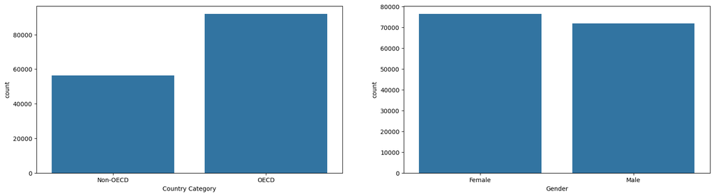

```python
plt.figure(figsize=[20,5])
# barchart plot of "OECD" and "Non-OECD"
plt.subplot(1,2,1)
barchart('OECD','Country Category')
# barchart plot of gender
plt.subplot(1,2,2)
barchart('ST04Q01','Gender')
```

#### Question 7:

How much do pupils generally like to solve complex problem?

#### Visualization

I'd also like to see for those who had a very high performance in mathematics how much extent they like to solve complex problem. I'll create a dataframe subset for those who score above 700 in Mathematics, and compare their degree of likeness for solving complex problem.

```python
# create a subset of the dataframe by Mathematics performance score greater than 700.
pisa_subset = pisa_clean_df[['ST29Q01','PV1MATH','ST94Q14','ST04Q01','ST29Q01']]
pisa_subset_700 = pisa_subset[pisa_subset['PV1MATH']>700]
```

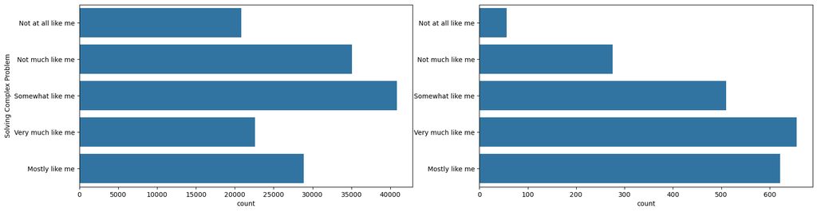

```python
plt.figure(figsize=[20,5])
# a barchart plot for pupils degree of likeness for complex problem solving (all students)
plt.subplot(1,2,1)
barchart('ST94Q14','Solving Complex Problem',long=True)
# a barchart plot for pupils degree of likeness for complex problem solving (students performance score > 700 only)
plt.subplot(1,2,2)
sb.countplot(data=pisa_subset_700,y='ST94Q14',color=sb.color_palette()[0]);
plt.ylabel(None);
```

#### Observation:

Generally (left plot), pupils who opined that a likeness for solving complex problem is not really like them are greater than those who say it's much or mostly like them.

But a closer look (right plot) at those who scored higher than 700 in Mathematics, shows that most of them are complex problem solvers.

### Discuss the distribution(s) of your variable(s) of interest. Were there any unusual points? Did you need to perform any transformations?

> The distribution of my variable of interest - 'PV1MATH' (Perfomance Value in Mathematics) - is normal. No unsual points were detected and no outliers were seen. I did not need to perform any transformations since it is normal distributed.

### Of the features you investigated, were there any unusual distributions? Did you perform any operations on the data to tidy, adjust, or change the form of the data? If so, why did you do this?

> The "OUTHOURS" column (Out-of-School Study Hours) had a right-skewed distribution. To apply a log transformation directly is impossible because it contains zero values of hour. I adjust the '0.0' hour values to '0.001', since 0.001 is as good as 0.0 .\ The elimination of zeroes allowed me to make a scaling and log transformation. Aside this feature, no unusual distribution was observed for the other features I investigated.\ At the cleaning phase,I had dropped all null values present in the columns I investigated, so that I have less missing values. I also changed the ordinal variables to a categorical datatype for easy ordering when a plot is to be created.

## Bivariate Exploration

```python
# chosed a color first,in order to avoid code repetition in subsequent plots
base_color = sb.color_palette()[0]
```

#### Question 1:

What is the relationship between Out-of-School Study Time and Pupil Performance in Mathematics ?

#### Visualization

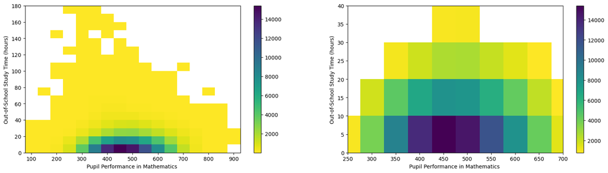

```python
# Heat map of Pupil performannces against Out-of-school study time.
plt.figure(figsize=[20,5])
# create bin edges
bins_x = np.arange(pisa_clean_df['PV1MATH'].min(),pisa_clean_df['PV1MATH'].max()+50,50)
bins_y = np.arange(0,180+10,10)
# create the heatmap
plt.subplot(1,2,1)
plt.hist2d(data = pisa_clean_df, x = 'PV1MATH', y = 'OUTHOURS',cmin=0.5, cmap='viridis_r', bins = [bins_x,bins_y]);
plt.colorbar()
plt.ylabel("Out-of-School Study Time (hours)")
plt.xlabel('Pupil Performance in Mathematics ')
# zoom in to see the deeply colored region
plt.subplot(1,2,2)
plt.hist2d(data = pisa_clean_df, x = 'PV1MATH', y = 'OUTHOURS',cmin=750.0, cmap='viridis_r', bins = [bins_x,bins_y]);
plt.colorbar()
plt.xlim(250,700)
plt.ylim(0,40);
plt.ylabel("Out-of-School Study Time (hours)")
plt.xlabel('Pupil Performance in Mathematics ');
```

#### Observation :

1. Majority of students who studied outside school for *at most 10-15 hours* had an *average performance* in Mathematics.
2. Some students also studied for the *same number of hours* yet had an *excellent performance* in Mathematics.
3. On the contrary, some students who also had an ouside school study hours of *at most 10 hours* performed *poorly*.

\ As we move up the Heatmap, those who made extra effort to study for longer hours ended up performing either excellently or averagely.

This could be due to difference in rate of assimilation or school reading material is too hard.\ Next up is the relationship between 'Mathematics Performance' and 'Attribution to Failure - Reading Material is too Hard'

#### Question 2:

What is the relationship between "Average Pupil Performance in Mathematics" and "Attribution to failure - Material too Hard ?

#### Visualization

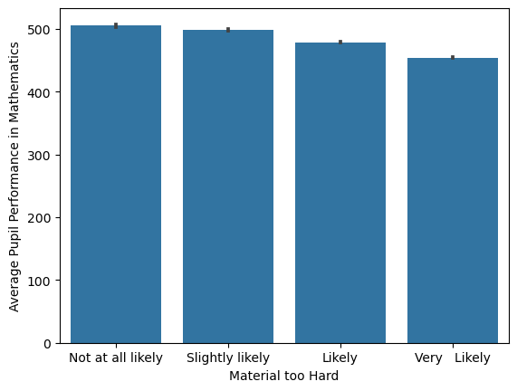

```python
# Bar plot of Pupil performance against "Failure - material too hard"
sb.barplot(data = pisa_clean_df, x = 'ST44Q05', y ='PV1MATH',color=base_color);
plt.ylabel('Average Pupil Performance in Mathematics')
plt.xlabel('Material too Hard');
```

#### Observation:

The average performance score in Mathematics slightly decreases as we move to the right from "Not at all likely" to "Very likely".

#### Question 3:

What is the relationship between 'Average Pupil Performance in Mathematics' and 'Enjoy Reading Mathematics'?

#### Visualization

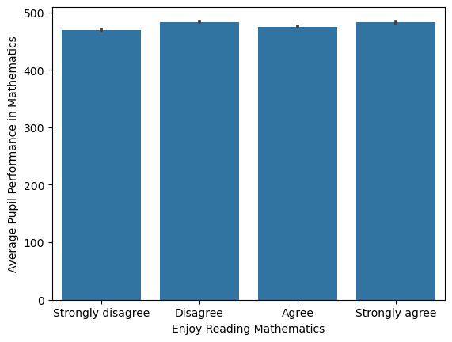

```python
# Bar plot of Average Pupil performance against interest in reading Mathematics
sb.barplot(data = pisa_clean_df, x = 'ST29Q01', y = 'PV1MATH',color=base_color);
plt.ylabel('Average Pupil Performance in Mathematics')
plt.xlabel('Enjoy Reading Mathematics');
```

#### Observation:

There is not a monotonic trend. I observe that the mean performance slightly increases from"Strongly disagree" to "disagree", and the same slight increase occur from "Agree" to "Strongly" agree.

#### Question 4:

Could there be a relationshp between "Possession of Textbooks" and Mean Performnce ?

#### Visualization

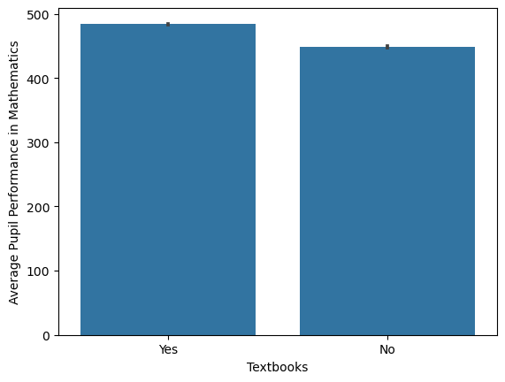

```python
# Barplot of mean performance against possession of textbook.
sb.barplot(data = pisa_clean_df, x = 'ST26Q10', y = 'PV1MATH',color=base_color);
plt.ylabel('Average Pupil Performance in Mathematics')
plt.xlabel('Textbooks');
```

#### Observation:

Pupils who possess textbooks have higher average performance than those who do not.

#### Question 5:

What is the relationship amongst the following three qualitative features : "Textbooks","Interest in reading Maths" and "Material too hard"

#### Visualization

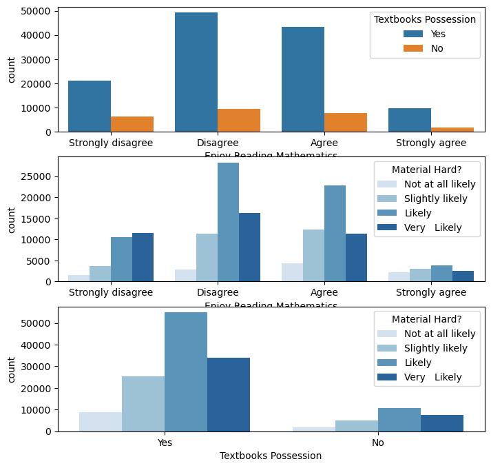

```python
# create a figure with three rows and 1 column, then make an adapted barchart for bivariate analysis.
plt.figure(figsize=[8,8])

plt.subplot(3,1,1)
sb.countplot(data=pisa_clean_df,x='ST29Q01',hue='ST26Q10');
plt.xlabel('Enjoy Reading Mathematics')
plt.legend(title='Textbooks Possession')

plt.subplot(3,1,2)
sb.countplot(data=pisa_clean_df,x='ST29Q01',hue='ST44Q05',palette='Blues');
plt.xlabel('Enjoy Reading Mathematics')
plt.legend(title ='Material Hard?')

plt.subplot(3,1,3)
sb.countplot(data=pisa_clean_df,x='ST26Q10',hue='ST44Q05',palette='Blues');
plt.legend(title ='Material Hard?')
plt.xlabel('Textbooks Possession');
```

#### Observation:

1. Irrespective of the pupils' level of interest in Mathematics - Enjoy Reading, those who possess textbook are more than those wo don't.
2. Across all degrees of interest to Mathematics, there follows the same trend of distribution for the degrees of attribution to failure - material is too hard. Except for a slight difference in "Strongly disagree" where "very likely" had the highest attribution to failure.
3. Same trend of distribution for material too hard is observed across those who have textbook and those who doesn't.

#### Question 6:

Is there a relationship between "Out-of-school study time" and "Material too hard"

#### Visualization

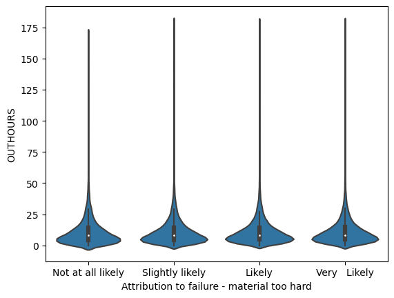

```python
# create a violin plot
sb.violinplot(data = pisa_clean_df, x = 'ST44Q05', y = 'OUTHOURS',color=base_color);
plt.xlabel('Attribution to failure - material too hard');
```

#### Observation:

There is very little or no difference in the distribution of out-of-school study hours for each category. Too many outliers are spotted as well.

#### Question 7:

Which gender had the highest mean performance in Mathematics?

#### Visualization

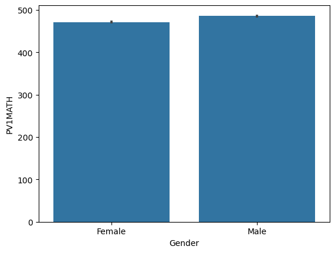

```python
sb.barplot(data = pisa_clean_df, x = 'ST04Q01', y ='PV1MATH',color=base_color);
plt.xlabel('Gender');
```

#### Observation:

Males have a slightly higher mean performance in Mathematics than Females.

#### Question 8:

Is there a significant performance difference between OECD countries and Non-OECD countries?

#### Visualization

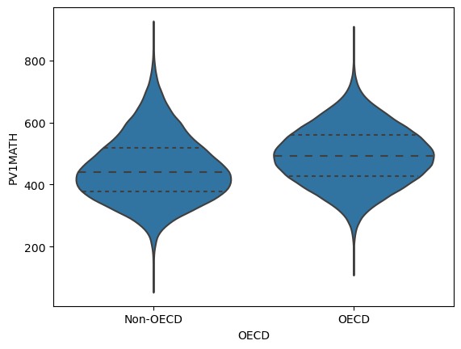

```python
#make a violin plot
sb.violinplot(data = pisa_clean_df, x = 'OECD', y ='PV1MATH' ,inner = 'quartile',color=base_color);
```

#### Observation:

Pupils from OECD member countries have higher mean performance than their counterpart who are from non member countries.

#### Question 9:

What is the trend in "gender" count across the degrees of "Interest in Mathematics"?\ And what is trend in "gender" count across the degrees of "Atrribution to failure - material too hard"?

#### Visualization

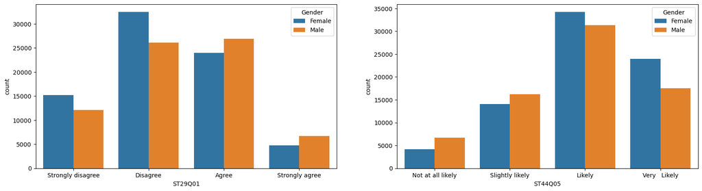

```python
# create a figure and two subplots
fig = plt.figure(figsize=[20,5])

plt.subplot(1,2,1)
sb.countplot(data=pisa_clean_df,x='ST29Q01',hue='ST04Q01');
plt.legend(title='Gender')

plt.subplot(1,2,2)
sb.countplot(data=pisa_clean_df,x='ST44Q05',hue='ST04Q01');
plt.legend(title='Gender');
```

#### Question 10:

What is the distribution of mathematics performance across all the degrees of interest in mathematics?

#### Visualization

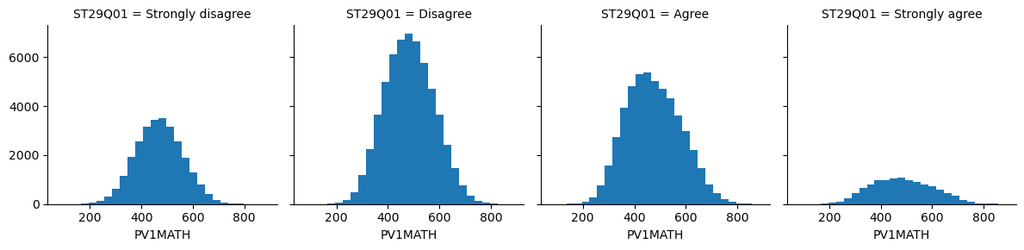

```python
# Use a FacetGrid approach to view the distribution of performance value across degrees of Maths interest.
g = sb.FacetGrid(data=pisa_clean_df,col='ST29Q01')
g.map(plt.hist,'PV1MATH',bins=np.arange(pisa_clean_df['PV1MATH'].min(),pisa_clean_df['PV1MATH'].max(),30));
```

#### Observation:

The Maths performance distribution for "Disagree" is more peaked than "agree". Generally they all have a normal distribution.\ Suprisingly,the highest degree of interest -"Strongly agree" - had the lowest peak.

#### Question 11:

What is the distribution of mathematics performance across all the degrees of "Material too hard"?

#### Visualization

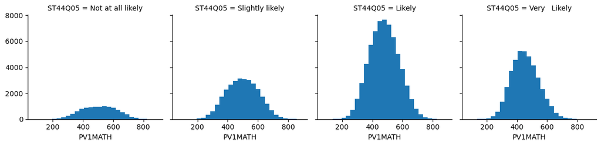

```python
# Use a FacetGrid approach to view the relationship among distributions of performance value across degrees of attribution to failure - material too hard
g = sb.FacetGrid(data=pisa_clean_df,col='ST44Q05')
g.map(plt.hist,'PV1MATH',bins=np.arange(pisa_clean_df['PV1MATH'].min(),pisa_clean_df['PV1MATH'].max(),30));
```

#### Observation:

"Likely" and "very likely" had the first highest and second highest peak of all the distributions respectively. Generally, they all have a normal distribution.

## Multivariate Exploration

#### Question:

Which gender has the highest frequency of distribution for those whose performance score is above 700 in Mathematics, across the degrees of likeness for problem solving ?

#### Visualization

```
A Facet Grid showing the right-most tail distribution of 'PV1MATH' (score > 700), with 'degree of Likeness for problem solving' (at column level) and 'Gender' (at row level).
```

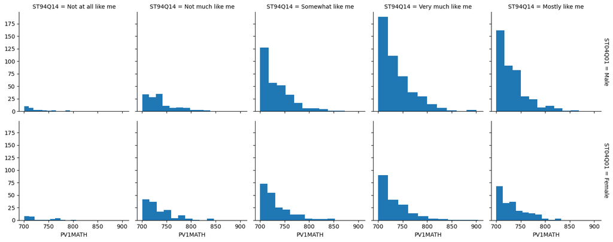

```python
print("A Facet Grid showing the right-most tail distribution of 'PV1MATH' (score > 700), with 'degree of Likeness for problem solving' (at column level) and 'Gender' (at row level).")
# a Facet Grid to compare the degree of Likeness for problem solving (at column level) across "Gender" (at row level), for pupils Maths performance score greater than 700
g = sb.FacetGrid(data=pisa_subset_700,col='ST94Q14', row="ST04Q01",margin_titles=True)
g.map(plt.hist,"PV1MATH");
```

#### Question:

What is the multivariate relationship among study time(hours), Interest in reading mathematics, and attribution to failure - material too hard.

#### Visualization

```
A FacetGrid showing the sub-distributions of 'OUTHOURS' with the degrees of 'Attribution to failure-material too hard'(at column level) and the degrees of 'Interest in Mathematics - Enjoy reading' (at row level).
```

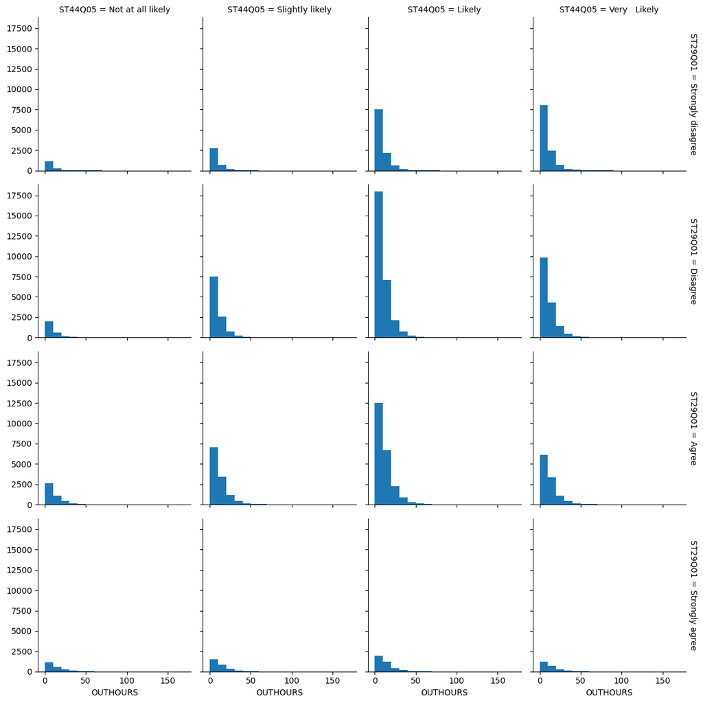

```python
print("A FacetGrid showing the sub-distributions of 'OUTHOURS' with the degrees of 'Attribution to failure-material too hard'(at column level) and the degrees of 'Interest in Mathematics - Enjoy reading' (at row level).")
# a facetgrid of "OUTHOURS" distribution, with "ST44Q05"(column level) and "ST29Q01" at row level
g = sb.FacetGrid(data=pisa_clean_df,col='ST44Q05', row='ST29Q01',margin_titles=True)
g.map(plt.hist,'OUTHOURS',bins=np.arange(pisa_clean_df['OUTHOURS'].min(),pisa_clean_df['OUTHOURS'].max(),10));
```

### Talk about some of the relationships you observed in this part of the investigation. Were there features that strengthened each other in terms of looking at your feature(s) of interest?

> The male gender is more for those whose performance score is above 700 in Mathematics, than the female gender.

### Were there any interesting or surprising interactions between features?

> I was expecting a significant increase in study time for those who "strongly agree" to reading mathematics,who also perceived the material to be not-at-all-likely hard. Suprisingly, the distribution generally looks similar in shape for all.

## Conclusions

### Limitations :

1. I couldn't show strong correlations because most of the numerous columns in this dataset are categorical in nature.
2. The dataset is greatly based on questionnaire, there could be human errors while answering: some pupils could perceive a wrong notion of themselves,while a work-it-out mathematical question would prove them wrong.